# Data Science Specialization - Capstone Project

Jordi Overeem

25 juli 2018

## Introduction

This is the Exploratory Data Analysis part of the milestone report of the Coursera Data Science Capstone project. The end goal is to build an application which uses a predictive text model. The end user will provide a word or a phrase and the application will try to predict the next word(s). The model will use a corpus (a collection of English text) that is compiled from 3 sources: news, blogs, and tweets.

First, data will be loaded and cleaned. Next, Natural Language Processing applications in R (tm and RWeka) are used for tokenizing n-grams as a first step toward building a predictive model.

## Set directory and load libraries

```r
setwd("C:/Users/joov2/Desktop/Capstone Project")
library(tm, warn.conflicts=F, quietly=T)
library(ggplot2, warn.conflicts=F, quietly=T)
library(dplyr, warn.conflicts=F, quietly=T)
library(RWeka, warn.conflicts=F, quietly=T)
library(stringi, warn.conflicts=F, quietly=T)
```

## Load data

It is assumed that the data source is: //d396qusza40orc.cloudfront.net/dsscapstone/dataset/Coursera-SwiftKey.zip. These data will be used for training a model further on in the project. The data is downloaded from this source and unzipped on Desktop. From here it can be loaded.

```r
blogs_file <- file("./Coursera-SwiftKey/final/en_US/en_US.blogs.txt","r")
blogs <- readLines(blogs_file, encoding = "UTF-8", skipNul = TRUE)
close(blogs_file)

news_file <- file("./Coursera-SwiftKey/final/en_US/en_US.news.txt","r")
news <- readLines(news_file, encoding = "UTF-8", skipNul = TRUE)
close(news_file)

twitter_file <- file("./Coursera-SwiftKey/final/en_US/en_US.twitter.txt","r")
twitter <- readLines(twitter_file, encoding = "UTF-8", skipNul = TRUE)
close(twitter_file)
```

## Descriptive statistics

With the code below the number of characters, number of words and the number of lines are determined for all 3 datasets. Also, some descriptive statistics on the number of words per line and the number of characters per line are calculated.

```r
words_per_line <- sapply(list(blogs,news,twitter),function(x) summary(stri_count_words(x))[c('Min.','Median','Mean','Max.')])
chars_per_line <- sapply(list(blogs,news,twitter), function(x) summary(nchar(x))[c('Min.','1st Qu.','Median','Mean','3rd Qu.','Max.')])

rownames(words_per_line) <- c('Min._words_per_line','Median_words_per_line','Mean_words_per_line','Max._words_per_line')
rownames(chars_per_line) <- c('Min._chars_per_line', '1st_Qu._chars_per_line', 'Median_chars_per_line', 'Mean_chars_per_line', '3rd_Qu._chars_per_line', 'Max._chars_per_line')

counts <- data.frame(Datasource=c("blogs","news","twitter"),
  t(rbind(sapply(list(blogs,news,twitter),stri_stats_general)[c('Lines','Chars'),],
    Words=sapply(list(blogs,news,twitter),stri_stats_latex)['Words',]
    )
  ))

stats_lines <- data.frame(Datasource=c("blogs","news","twitter"),
  t(words_per_line)
  )

stats_chars <- data.frame(Datasource=c("blogs","news","twitter"),
  t(chars_per_line)
  )

counts
```

```
##   Datasource   Lines     Chars    Words
## 1      blogs  899288 206824382 37570839
## 2       news   77259  15639408  2651432
## 3    twitter 2360148 162096241 30451170
```

```r
stats_lines
```

```
##   Datasource Min._words_per_line Median_words_per_line Mean_words_per_line
## 1      blogs                   0                    28            41.75108
## 2       news                   1                    32            34.61779
## 3    twitter                   1                    12            12.75065
##   Max._words_per_line
## 1                6726
## 2                1123
## 3                  47
```

```r
stats_chars
```

```
##   Datasource Min._chars_per_line X1st_Qu._chars_per_line
## 1      blogs                   1                      47
## 2       news                   2                     111
## 3    twitter                   2                      37
##   Median_chars_per_line Mean_chars_per_line X3rd_Qu._chars_per_line
## 1                   156           229.98695                     329
## 2                   186           202.42830                     270
## 3                    64            68.68054                     100
##   Max._chars_per_line
## 1               40833
## 2                5760
## 3                 140
```

One can notice that on average blogs seem to have the most words per line and tweets have the least words per line. This was to be expected since Twitter has limits on the number of characters in tweets.

Also interesting is the fact that while the mean and max number of words in lines are both higher for blogs compared to news, the median is lower suggesting greater variance in linesize with blogs.

## Clean and sample data

With the code below non-English characters are removed and the data are compiled into a sample dataset that is composed of 1% of each of the 3 original datasets (blogs, news, twitter). Next, the data are transformed into a cleaned corpus by:

1. converting al characters to lower case;
2. removing punctuation;
3. removing numbers;
4. stripping white space and
5. converting to plain text.

```r
blogs <- iconv(blogs, "latin1", "ASCII", sub="")
news <- iconv(news, "latin1", "ASCII", sub="")
twitter <- iconv(twitter, "latin1", "ASCII", sub="")

set.seed(2507)
sample <- c(sample(blogs, length(blogs)/100), sample(news, length(news)/100), sample(twitter, length(twitter)/100))

corpus <- VCorpus(VectorSource(sample))
corpus <- tm_map(corpus, tolower)
corpus <- tm_map(corpus, removePunctuation)
corpus <- tm_map(corpus, removeNumbers)
corpus <- tm_map(corpus, stripWhitespace)
corpus <- tm_map(corpus, PlainTextDocument)
```

## Tokenize and calculate frequencies of N-Grams

The RWeka package is used for tokenizing the sample, creating matrices of uni-, bi- and trigrams and calculating the frequencies of the n-grams.

```r
# Functions for tokenizing sample
uni <- function(x) NGramTokenizer(x, Weka_control(min = 1, max = 1))
bi <- function(x) NGramTokenizer(x, Weka_control(min = 2, max = 2))
tri <- function(x) NGramTokenizer(x, Weka_control(min = 3, max = 3))

# Create matrices
uni_matrix <- TermDocumentMatrix(corpus, control = list(tokenize = uni))
bi_matrix <- TermDocumentMatrix(corpus, control = list(tokenize = bi))
tri_matrix <- TermDocumentMatrix(corpus, control = list(tokenize = tri))

# Calculate frequencies
uni_corpus <- findFreqTerms(uni_matrix, lowfreq = 100, highfreq = Inf)
bi_corpus <- findFreqTerms(bi_matrix, lowfreq = 50, highfreq = Inf)
tri_corpus <- findFreqTerms(tri_matrix, lowfreq = 30, highfreq = Inf)

uni_frequencies <- rowSums(as.matrix(uni_matrix[uni_corpus,]))
df1 <- data.frame(word = names(uni_frequencies), frequency = uni_frequencies)

bi_frequencies <- rowSums(as.matrix(bi_matrix[bi_corpus,]))
df2 <- data.frame(word = names(bi_frequencies), frequency = bi_frequencies)

tri_frequencies <- rowSums(as.matrix(tri_matrix[tri_corpus,]))
df3 <- data.frame(word = names(tri_frequencies), frequency = tri_frequencies)
```

## Plot top N-Grams

Finally, plots are made from the top-30 uni-, bi- and trigrams by frequency:

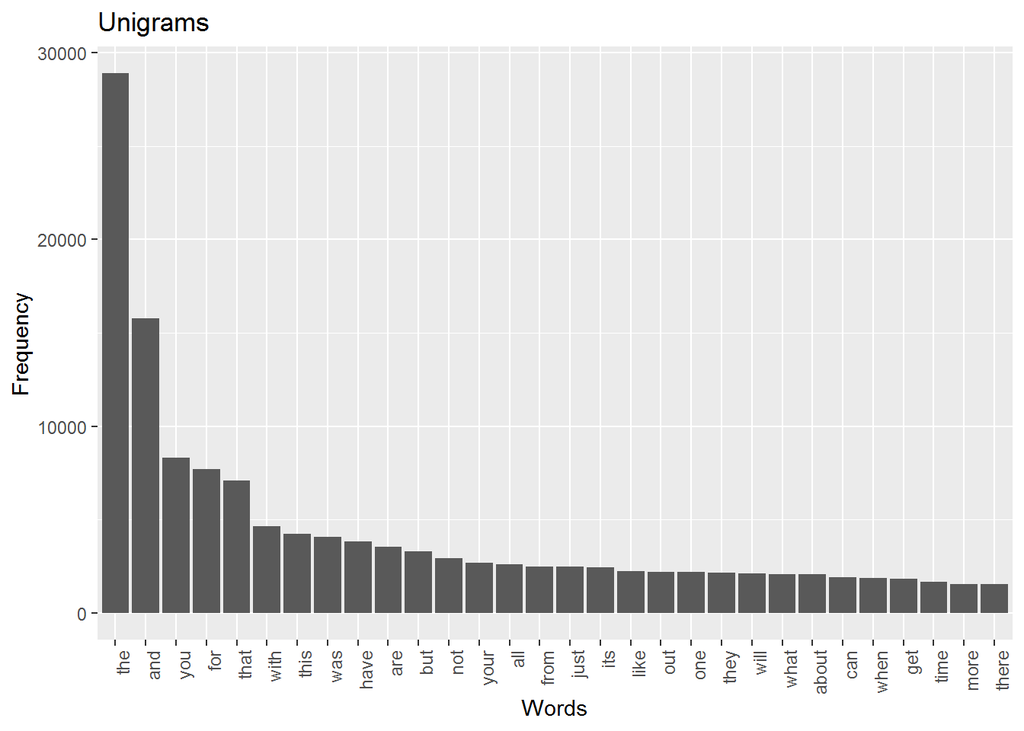

```r
plot_function <- function(data, title, count) {
  df <- data[order(-data$frequency),][1:count,]
  ggplot(df, aes(x = reorder(word, -frequency), y = frequency)) + geom_bar(stat = "identity") +
    labs(title = title) + xlab("Words") + ylab("Frequency") +
    theme(axis.text.x = element_text(angle = 90, hjust = 1))
}

plot1 <- plot_function(df1,"Unigrams",30)
plot2 <- plot_function(df2,"Bigrams",30)
plot3 <- plot_function(df3,"Trigrams",30)
plot1
```

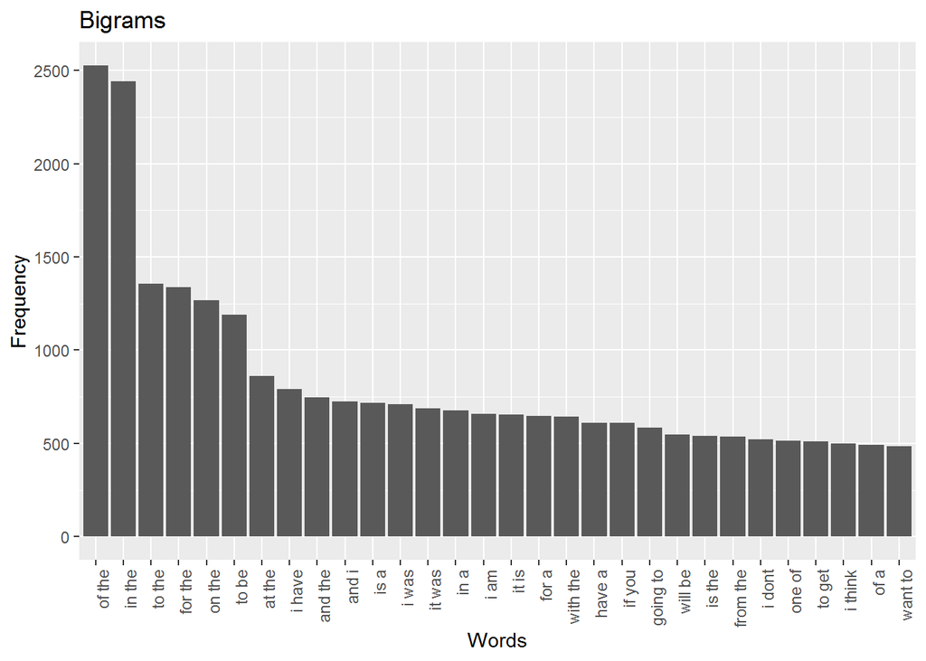

```r
plot2
```

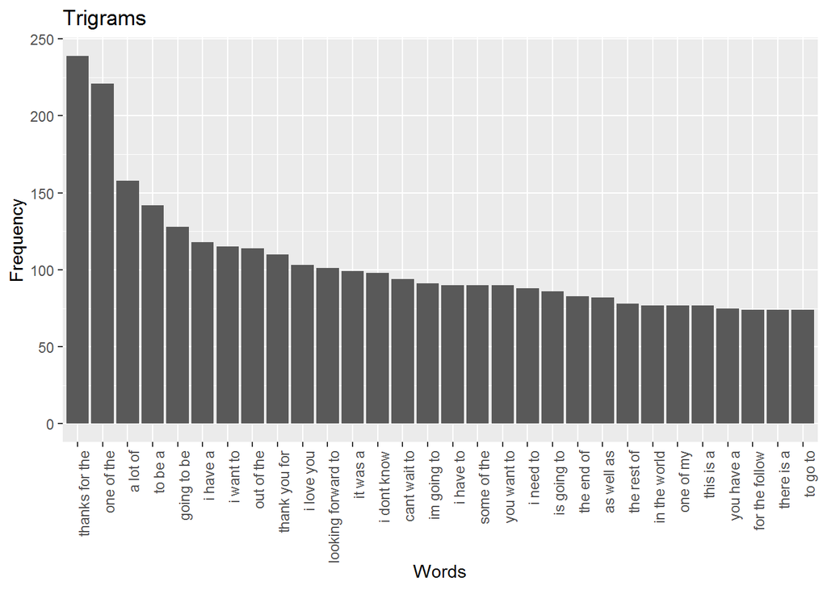

```r
plot3
```

## Plans for creating the prediction algorithm and Shiny app

The next steps are to:

1. look in to the possibility of creating a “small library” with stored n-grams, just for efficiently looking up the most common n-grams without having to run a complete model;
2. build a predictive algorithm which uses a comparable n-gram model as in the analysis above which looks up the most likely n-grams by frequency;
3. build an application with Shiny in which the predictive algorithm is deployed that shows the most likely n-grams after typing a phrase, inclusing an embedded tutorial. Probably, 4- and 5-grams will be added as well;
4. finetune the application so that it works relatively fast and
5. create a slide deck as reference work.